# Homework 10

Homework 10 by Sana Khan: I consulted with the textbook to complete the homework

2. Download and library the nlme package and use data (“Blackmore”) to activate the Blackmore data set. Inspect the data and create a box plot showing the exercise level at different ages. Run a repeated measures ANOVA to compare exercise levels at ages 8, 10, and 12 using aov().

```r
summary(aov(exercise ~ age + Error(subject), data=black_filtered))
```

```
Error: subject
           Df Sum Sq Mean Sq F value Pr(>F)
Residuals 186   1979   10.64

Error: Within
           Df Sum Sq Mean Sq F value   Pr(>F)
age         2  102.1   51.04   28.23 3.87e-12 ***
Residuals 372  672.7    1.81
---
Signif. codes:  0 ‘***’ 0.001 ‘**’ 0.01 ‘*’ 0.05 ‘.’ 0.1 ‘ ’ 1
```

5. Given that the AirPassengers data set has a substantial growth trend, use diff() to cre- ate a differenced data set. Use plot() to examine and interpret the results of differenc- ing. Use cpt.var() to find the change point in the variability of the differenced time series. Plot the result and describe in your own words what the change point signifies.

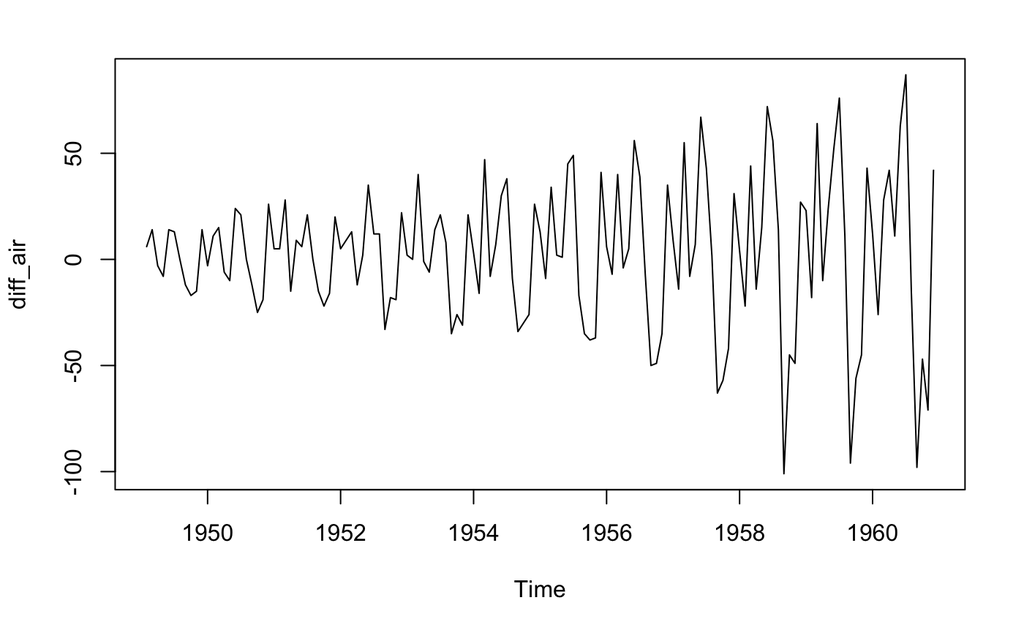

```r
library(changepoint)

data("AirPassengers")
diff_air <- diff(AirPassengers)

plot(diff_air)
```

```r
cpt.var(diff_air)
```

```
Class 'cpt' : Changepoint Object
       ~~   : S4 class containing 12 slots with names
              cpttype date version data.set method test.stat pen.type pen.value minseglen cpts ncpts.max param.est

Created on  : Fri Nov  4 07:37:30 2022

summary(.)  :
----------
Created Using changepoint version 2.2.4
Changepoint type      : Change in variance
Method of analysis    : AMOC
Test Statistic  : Normal
Type of penalty       : MBIC with value, 14.88853
Minimum Segment Length : 2
Maximum no. of cpts   : 1
Changepoint Locations : 76
```

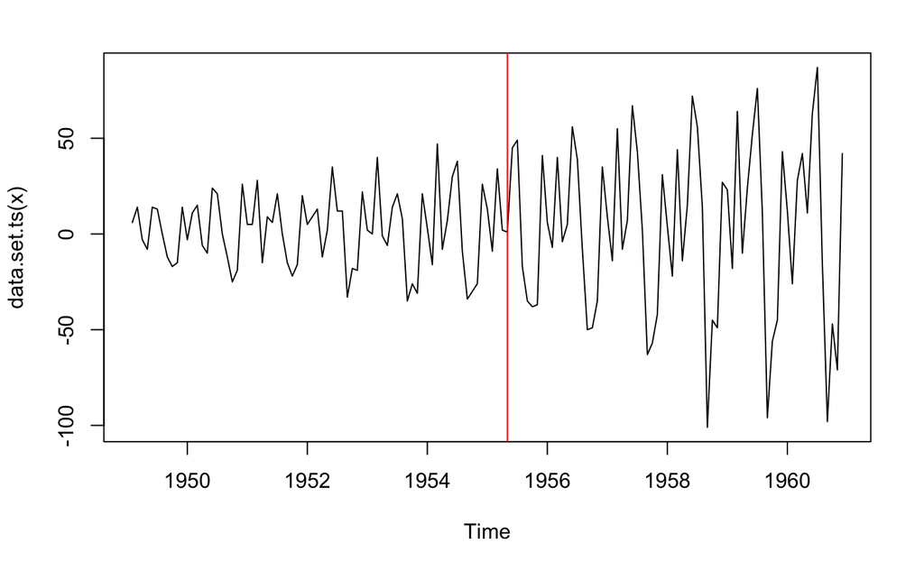

```r
plot(cpt.var(diff_air))
```

The command cpt.var calculates us when there is a changepoint in our dataset. The plot above shows the red line as the changepoint, which is sometime in 1955.

Use cpt.mean() on the AirPassengers time series. Plot and interpret the results. Com- pare the change point of the mean that you uncovered in this case to the change point in the variance that you uncovered in Exercise 5. What do these change points suggest about the history of air travel?

```r
airmean=cpt.mean(AirPassengers)
airmean
```

```
Class 'cpt' : Changepoint Object
       ~~   : S4 class containing 12 slots with names
              cpttype date version data.set method test.stat pen.type pen.value minseglen cpts ncpts.max param.est

Created on  : Fri Nov  4 07:37:30 2022

summary(.)  :
----------
Created Using changepoint version 2.2.4
Changepoint type      : Change in mean
Method of analysis    : AMOC
Test Statistic  : Normal
Type of penalty       : MBIC with value, 14.90944
Minimum Segment Length : 1
Maximum no. of cpts   : 1
Changepoint Locations : 77
```

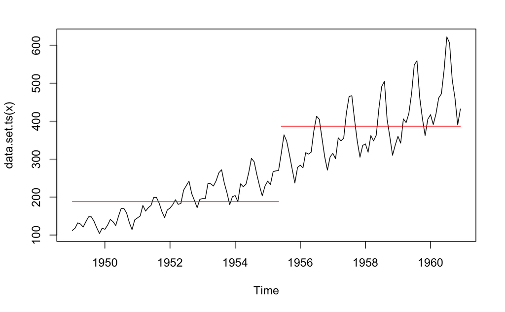

```r
plot(airmean)
```

```r
airmean2 <- cpt.mean(AirPassengers, class=FALSE)

airmean2["conf.value"]
```

```
conf.value
         1
```

The plot shows us that there has been a shift in the mean over time, which was sometime in 1955.

7.Find historical information about air travel on the Internet and/or in reference materials that sheds light on the results from Exercises 5 and 6. Write a mini-article (less than 250 words) that interprets your statistical findings from Exercises 5 and 6 in the context of the historical information you found.

According to https://theconversation.com/longing-for-the-golden-age-of-air-travel-be-careful-what-you-wish-for-34177, jets were intorduced in 1950, which meant it was faster to travel then before. In the 50’s and 60’s it become a bit more affordable to travel, with the introduction of new fares. The demographics of who was flying also changed, with more women and younger people flying.

9.Use bcp() on the AirPassengers time series. Plot and interpret the results. Make sure to contrast these results with those from Exercise 6.

```r
#install.packages("bcp")
library(bcp)


bcpAir <- bcp(as.vector(AirPassengers), mcmc=1000, p0=1)
summary(bcpAir)
```

```
Bayesian Change Point (bcp) summary:


Probability of a change in mean and posterior means:

    Probability    X1
1         0.018 130.7
2         0.025 131.0
3         0.022 131.4
4         0.013 131.7
5         0.021 131.8
6         0.030 132.1
7         0.022 132.4
8         0.023 132.5
9         0.022 132.5
```

[output cut: 135 more lines]

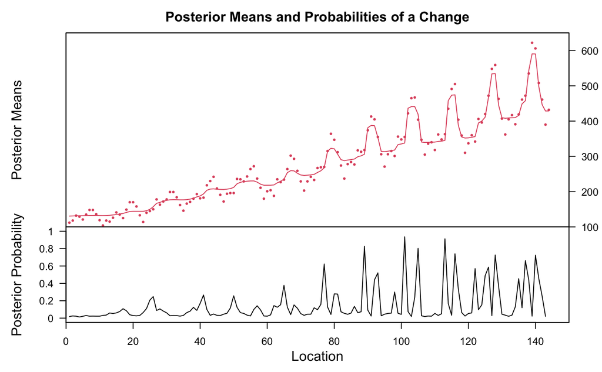

```r
plot(bcpAir)
```

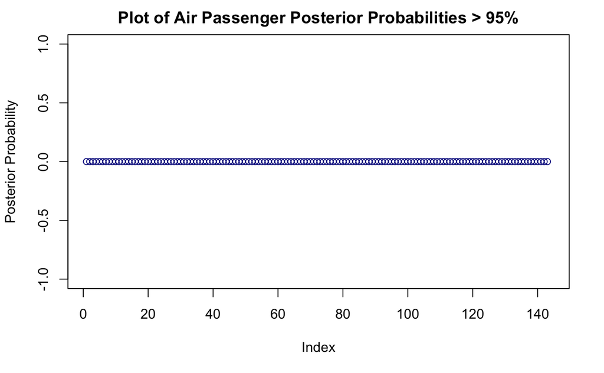

```r
plot(bcpAir$posterior.prob >.95,
     main="Plot of Air Passenger Posterior Probabilities > 95%",
     ylab="Posterior Probability", col="darkblue")
```